# Tutorial 11: Pseudorandom Numbers and Monte Carlo Integration

Dexter Barrows

Tuesday March 29, 2016

[Documentation reference](http://docs.scipy.org/doc/numpy/reference/routines.random.html).

## DIY Pseudorandom Number Generation

True random numbers are impossible for computers to generate; they are deterministic machines by design. Instead we must rely on pseudorandom number generation algorithms to produce sequences of numbers that are approximately random.

One of the oldest algorithms for producing pseudorandom number sequences $x_1, x_2, ...,x_n$ is a [Linear Congruential Generator](https://en.wikipedia.org/wiki/Linear_congruential_generator) (LCG). They are defined as

$$x_{n+1} = (a \cdot x_{n} + c) \mod m$$

LCGs are defined by their $(a,c,m)$ triplet. For example, the C99 generator uses the triplet $(a,c,m) = (1103515245, 12345, 2^{31})$. We can implement an LCG in Python fairly easily:

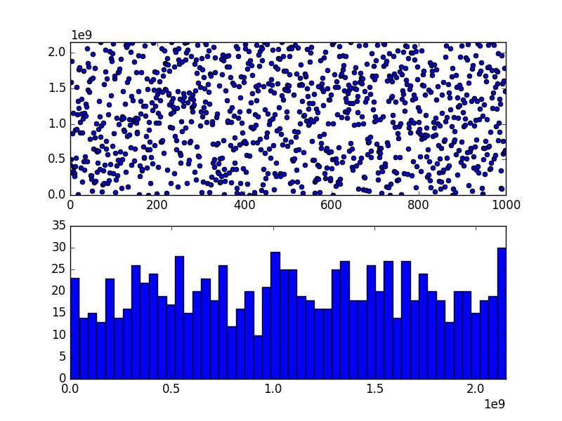

```python
import numpy as np
import matplotlib.pyplot as plt

def lcg_C99(n, x = 1024):
    '''
    Generates `n` pseudorandom numbers with `x` as a seed
    Uses C99 LCG triplet (1103515245, 12345, 2147483648)
    '''
    nums = np.zeros(n)
    curnum = x
    for i in range(0,n):
        curnum = (1103515245*curnum + 12345) % 2**31    # core LCG calculation
        nums[i] = curnum                                # save current number
    return(nums)

N = 1000
prng_nums = lcg_C99(N)                                  # numbers in [0,2^31-1]

plt.subplot(2,1,1)
plt.scatter(np.arange(N), prng_nums)                    # number against index
plt.axis([0, N, 0, 2**31])

plt.subplot(2,1,2)
plt.hist(prng_nums, bins = 50)                          # histogram of numbers
plt.axis([0, 2**31, 0, 35])

plt.savefig("tutpix/prngC99.png")
```

## Numpy PRNG

But using an LCG isn’t that great of an idea. Better: get Numpy to do the work for you, and get potentially better random numbers to boot.

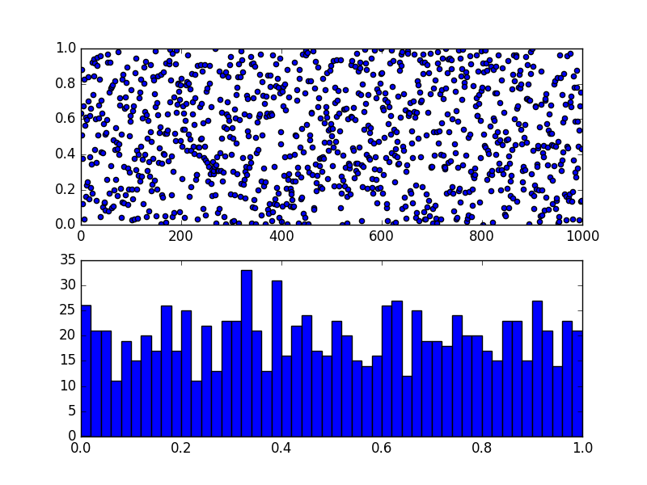

```python
import numpy as np
import numpy.random as npr
import matplotlib.pyplot as plt

N = 1000
prng_nums = npr.rand(N)                 # uniform random numbers in [0,1]

plt.subplot(2,1,1)
plt.scatter(np.arange(N), prng_nums)    # number against index
plt.axis([0, N, 0, 1])

plt.subplot(2,1,2)
plt.hist(prng_nums, bins = 50)          # histogram of numbers
plt.axis([0, 1, 0, 35])

plt.savefig("tutpix/prng_npr.png")
```

## Other Distributions

### Normal

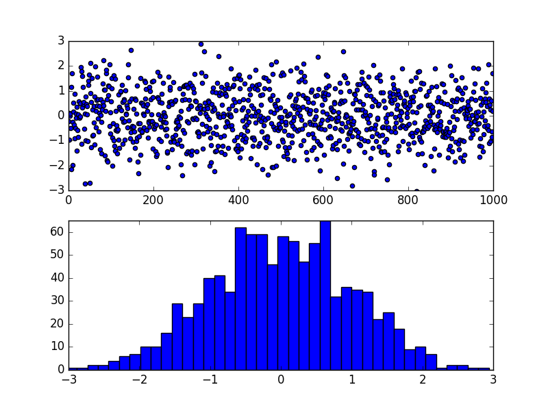

```python
import numpy as np
import numpy.random as npr
import matplotlib.pyplot as plt

N = 1000
prng_nums = npr.normal(size = N)        # Gaussian random numbers

plt.subplot(2,1,1)
plt.scatter(np.arange(N), prng_nums)    # number against index
plt.axis([0, N, -3, 3])

plt.subplot(2,1,2)
plt.hist(prng_nums, bins = 50)          # histogram of numbers
plt.axis([-3, 3, 0, 65])

plt.savefig("tutpix/npr_normal.png")
```

### Poisson

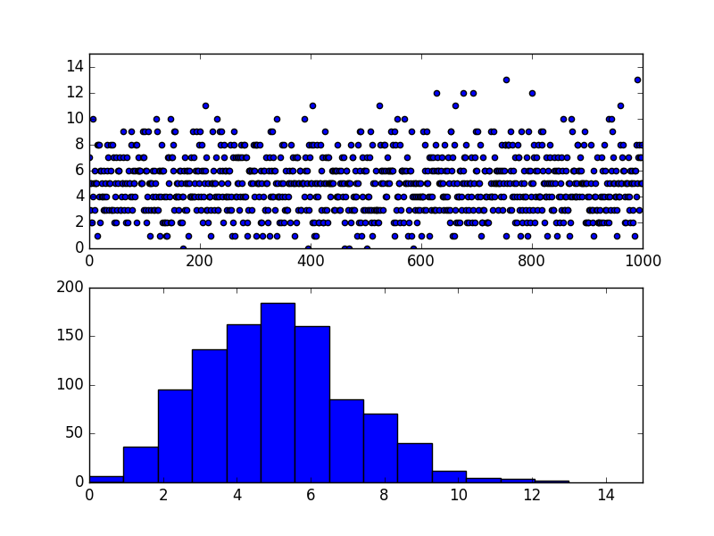

```python
import numpy as np
import numpy.random as npr
import matplotlib.pyplot as plt

N = 1000
prng_nums = npr.poisson(lam = 5, size = N) # Poisson random numbers

plt.subplot(2,1,1)
plt.scatter(np.arange(N), prng_nums)        # number against index
plt.axis([0, N, 0, 15])

plt.subplot(2,1,2)
plt.hist(prng_nums, bins = 14)              # histogram of numbers
plt.axis([0, 15, 0, 200])

plt.savefig("tutpix/npr_poisson.png")
```

## Seeds

As PRNG schemes are deterministic, they have ‘states’ that can be set so we can force the output to be consistent (say if we are doing testing). This is known as **seeding**.

```python
import numpy as np
import numpy.random as npr

N = 1000
npr.seed(1024)

a = npr.rand(N)
b = npr.rand(N)
print( np.all( a == b ) )   # Should be False

npr.seed(101)
a = npr.rand(N)
npr.seed(101)
b = npr.rand(N)
print( np.all( a == b ) )   # Should be True
```

```
## False
## True
```

## Monte Carlo Integration

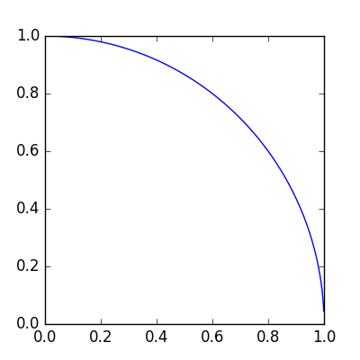

```python
import numpy as np
import matplotlib.pyplot as plt

x = np.arange(0, 1, 0.001)

plt.subplots(figsize=(4,4))
plt.plot(x, np.sqrt(1 - x**2))
plt.axis([0, 1, 0, 1])

plt.savefig("tutpix/circ.png")
```

We can get the answer analytically, but what if the function can’t be integrated? We can use Monte Carlo Integration. The basic procedure is we generate a bunch on random numbers in the unit square in the first quadrant, and see what proportion land inside the arc.

```
## Approximate area:  0.777
## Actual area:       0.7853981633974483
```

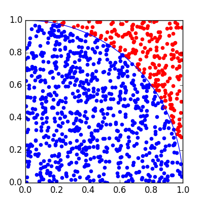

```python
import numpy as np
import numpy.random as npr
import matplotlib.pyplot as plt

x = np.arange(0, 1, 0.001)

plt.subplots(figsize=(4,4))
plt.plot(x, np.sqrt(1 - x**2))
plt.axis([0, 1, 0, 1])

N = 1000
goodlist = []
badlist = []
for i in range(N):
    x, y = npr.rand(2)
    if x**2 + y**2 <= 1:
        goodlist.append((x,y))
    else:
        badlist.append((x,y))

area = len(goodlist) / N
print("Approximate area: ", area)
print("Actual area:      ", np.pi/4)

x1, y1 = zip(*goodlist)
x2, y2 = zip(*badlist)

plt.scatter(x1, y1, color = 'b')
plt.scatter(x2, y2, color = 'r')

plt.savefig("tutpix/circfilled.png")
```